# Optimal Treatment Analysis

## Outcome Variable

**Outcome Variable:** ever_stunted

## Predictor Variables

**Intervention Variable:** fage

**Adjustment Set:**

- arm
- W_mage
- meducyrs
- feducyrs
- W_mhtcm
- W_mwtkg
- W_mbmi
- W_fhtcm
- single
- brthmon
- delta_W_mage
- delta_meducyrs
- delta_feducyrs
- delta_W_mhtcm
- delta_W_mwtkg
- delta_W_mbmi
- delta_W_fhtcm
- delta_single
- delta_brthmon

## Stratifying Variables

The analysis was stratified on these variable(s):

- agecat
- studyid
- country

## Data Summary

| agecat | studyid | country | fage | ever_stunted | n_cell | n |
| --- | --- | --- | --- | --- | --- | --- |
| 0-24 months | ki0047075b-MAL-ED | BANGLADESH | >=38 | 0 | 28 | 151 |
| 0-24 months | ki0047075b-MAL-ED | BANGLADESH | >=38 | 1 | 41 | 151 |
| 0-24 months | ki0047075b-MAL-ED | BANGLADESH | <32 | 0 | 7 | 151 |
| 0-24 months | ki0047075b-MAL-ED | BANGLADESH | <32 | 1 | 23 | 151 |
| 0-24 months | ki0047075b-MAL-ED | BANGLADESH | [32-38) | 0 | 23 | 151 |
| 0-24 months | ki0047075b-MAL-ED | BANGLADESH | [32-38) | 1 | 29 | 151 |
| 0-24 months | ki0047075b-MAL-ED | BRAZIL | >=38 | 0 | 22 | 79 |
| 0-24 months | ki0047075b-MAL-ED | BRAZIL | >=38 | 1 | 8 | 79 |
| 0-24 months | ki0047075b-MAL-ED | BRAZIL | <32 | 0 | 10 | 79 |
| 0-24 months | ki0047075b-MAL-ED | BRAZIL | <32 | 1 | 8 | 79 |
| 0-24 months | ki0047075b-MAL-ED | BRAZIL | [32-38) | 0 | 26 | 79 |
| 0-24 months | ki0047075b-MAL-ED | BRAZIL | [32-38) | 1 | 5 | 79 |
| 0-24 months | ki0047075b-MAL-ED | INDIA | >=38 | 0 | 16 | 161 |
| 0-24 months | ki0047075b-MAL-ED | INDIA | >=38 | 1 | 20 | 161 |
| 0-24 months | ki0047075b-MAL-ED | INDIA | <32 | 0 | 19 | 161 |
| 0-24 months | ki0047075b-MAL-ED | INDIA | <32 | 1 | 34 | 161 |
| 0-24 months | ki0047075b-MAL-ED | INDIA | [32-38) | 0 | 25 | 161 |
| 0-24 months | ki0047075b-MAL-ED | INDIA | [32-38) | 1 | 47 | 161 |
| 0-24 months | ki0047075b-MAL-ED | NEPAL | >=38 | 0 | 12 | 79 |
| 0-24 months | ki0047075b-MAL-ED | NEPAL | >=38 | 1 | 5 | 79 |
| 0-24 months | ki0047075b-MAL-ED | NEPAL | <32 | 0 | 9 | 79 |
| 0-24 months | ki0047075b-MAL-ED | NEPAL | <32 | 1 | 6 | 79 |
| 0-24 months | ki0047075b-MAL-ED | NEPAL | [32-38) | 0 | 28 | 79 |
| 0-24 months | ki0047075b-MAL-ED | NEPAL | [32-38) | 1 | 19 | 79 |
| 0-24 months | ki0047075b-MAL-ED | PERU | >=38 | 0 | 10 | 85 |
| 0-24 months | ki0047075b-MAL-ED | PERU | >=38 | 1 | 17 | 85 |
| 0-24 months | ki0047075b-MAL-ED | PERU | <32 | 0 | 8 | 85 |
| 0-24 months | ki0047075b-MAL-ED | PERU | <32 | 1 | 21 | 85 |
| 0-24 months | ki0047075b-MAL-ED | PERU | [32-38) | 0 | 7 | 85 |
| 0-24 months | ki0047075b-MAL-ED | PERU | [32-38) | 1 | 22 | 85 |

[output cut: 204 more lines]

The following strata were considered:

- agecat: 0-24 months, studyid: ki0047075b-MAL-ED, country: BANGLADESH
- agecat: 0-24 months, studyid: ki0047075b-MAL-ED, country: BRAZIL
- agecat: 0-24 months, studyid: ki0047075b-MAL-ED, country: INDIA
- agecat: 0-24 months, studyid: ki0047075b-MAL-ED, country: NEPAL
- agecat: 0-24 months, studyid: ki0047075b-MAL-ED, country: PERU
- agecat: 0-24 months, studyid: ki0047075b-MAL-ED, country: SOUTH AFRICA
- agecat: 0-24 months, studyid: ki0047075b-MAL-ED, country: TANZANIA, UNITED REPUBLIC OF
- agecat: 0-24 months, studyid: ki1000304b-SAS-CompFeed, country: INDIA
- agecat: 0-24 months, studyid: ki1000304b-SAS-FoodSuppl, country: INDIA
- agecat: 0-24 months, studyid: ki1119695-PROBIT, country: BELARUS
- agecat: 0-24 months, studyid: ki1135781-COHORTS, country: GUATEMALA
- agecat: 0-24 months, studyid: ki1135781-COHORTS, country: PHILIPPINES
- agecat: 0-24 months, studyid: ki1148112-LCNI-5, country: MALAWI
- agecat: 0-6 months, studyid: ki0047075b-MAL-ED, country: BANGLADESH
- agecat: 0-6 months, studyid: ki0047075b-MAL-ED, country: BRAZIL
- agecat: 0-6 months, studyid: ki0047075b-MAL-ED, country: INDIA
- agecat: 0-6 months, studyid: ki0047075b-MAL-ED, country: NEPAL
- agecat: 0-6 months, studyid: ki0047075b-MAL-ED, country: PERU
- agecat: 0-6 months, studyid: ki0047075b-MAL-ED, country: SOUTH AFRICA
- agecat: 0-6 months, studyid: ki0047075b-MAL-ED, country: TANZANIA, UNITED REPUBLIC OF
- agecat: 0-6 months, studyid: ki1000304b-SAS-CompFeed, country: INDIA
- agecat: 0-6 months, studyid: ki1000304b-SAS-FoodSuppl, country: INDIA
- agecat: 0-6 months, studyid: ki1119695-PROBIT, country: BELARUS
- agecat: 0-6 months, studyid: ki1135781-COHORTS, country: GUATEMALA
- agecat: 0-6 months, studyid: ki1135781-COHORTS, country: PHILIPPINES
- agecat: 0-6 months, studyid: ki1148112-LCNI-5, country: MALAWI
- agecat: 6-24 months, studyid: ki0047075b-MAL-ED, country: BANGLADESH
- agecat: 6-24 months, studyid: ki0047075b-MAL-ED, country: BRAZIL
- agecat: 6-24 months, studyid: ki0047075b-MAL-ED, country: INDIA
- agecat: 6-24 months, studyid: ki0047075b-MAL-ED, country: NEPAL
- agecat: 6-24 months, studyid: ki0047075b-MAL-ED, country: PERU
- agecat: 6-24 months, studyid: ki0047075b-MAL-ED, country: SOUTH AFRICA
- agecat: 6-24 months, studyid: ki0047075b-MAL-ED, country: TANZANIA, UNITED REPUBLIC OF
- agecat: 6-24 months, studyid: ki1000304b-SAS-CompFeed, country: INDIA
- agecat: 6-24 months, studyid: ki1000304b-SAS-FoodSuppl, country: INDIA
- agecat: 6-24 months, studyid: ki1119695-PROBIT, country: BELARUS
- agecat: 6-24 months, studyid: ki1135781-COHORTS, country: GUATEMALA
- agecat: 6-24 months, studyid: ki1135781-COHORTS, country: PHILIPPINES
- agecat: 6-24 months, studyid: ki1148112-LCNI-5, country: MALAWI

### Dropped Strata

Some strata were dropped due to rare outcomes:

- agecat: 0-24 months, studyid: ki0047075b-MAL-ED, country: SOUTH AFRICA
- agecat: 0-24 months, studyid: ki0047075b-MAL-ED, country: TANZANIA, UNITED REPUBLIC OF
- agecat: 0-6 months, studyid: ki0047075b-MAL-ED, country: BRAZIL
- agecat: 0-6 months, studyid: ki0047075b-MAL-ED, country: NEPAL
- agecat: 0-6 months, studyid: ki0047075b-MAL-ED, country: SOUTH AFRICA
- agecat: 0-6 months, studyid: ki1148112-LCNI-5, country: MALAWI
- agecat: 6-24 months, studyid: ki0047075b-MAL-ED, country: BRAZIL
- agecat: 6-24 months, studyid: ki0047075b-MAL-ED, country: NEPAL
- agecat: 6-24 months, studyid: ki0047075b-MAL-ED, country: PERU
- agecat: 6-24 months, studyid: ki0047075b-MAL-ED, country: SOUTH AFRICA
- agecat: 6-24 months, studyid: ki0047075b-MAL-ED, country: TANZANIA, UNITED REPUBLIC OF

## Methods Detail

We’re interested in the causal parameters $E[Y_a]$ for all values of $a \in \mathcal{A}$. These parameters represent the mean outcome if, possibly contrary to fact, we intervened to set all units to have $A=a$. Under the randomization and positivity assumptions, these are identified by the statistical parameters $\psi_a=E_W[E_{Y|A,W}(Y|A=a,W)]$. In addition, we’re interested in the mean of $Y$, $E[Y]$ under no intervention (the observed mean). We will estimate these parameters by using SuperLearner to fit the relevant likelihood factors – $E_{Y|A,W}(Y|A=a,W)$ and $p(A=a|W)$, and then updating our likelihood fit using a joint TMLE.

For unadjusted analyses ($W=\{\}$), initial likelihoods were estimated using Lrnr_glm to estimate the simple $E(Y|A)$ and Lrnr_mean to estimate $p(A)$. For adjusted analyses, a small library containing Lrnr_glmnet, Lrnr_xgboost, and Lrnr_mean was used.

Having estimated these parameters, we will then use the delta method to estimate relative risks and attributable risks relative to a prespecified baseline level of $A$.

# Results Detail

## Results Plots

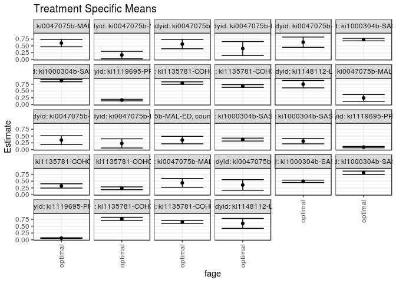

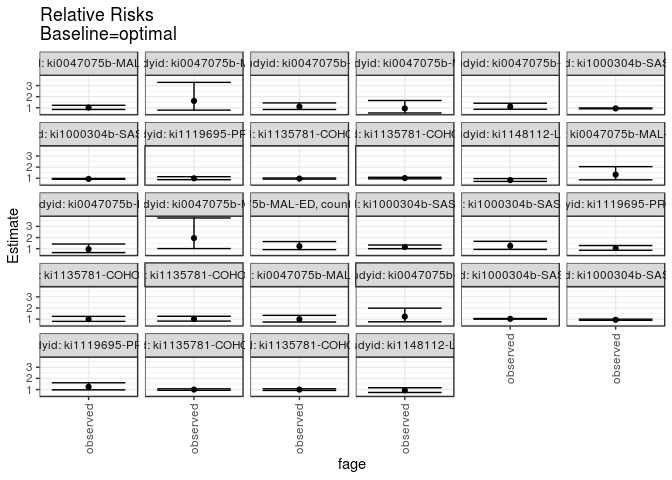

## Results Table

### Parameter: TSM

| agecat | studyid | country | intervention_level | baseline_level | estimate | ci_lower | ci_upper |
| --- | --- | --- | --- | --- | --- | --- | --- |
| 0-24 months | ki0047075b-MAL-ED | BANGLADESH | optimal | NA | 0.6035543 | 0.4669559 | 0.7401527 |
| 0-24 months | ki0047075b-MAL-ED | BRAZIL | optimal | NA | 0.1647102 | 0.0285476 | 0.3008727 |
| 0-24 months | ki0047075b-MAL-ED | INDIA | optimal | NA | 0.5673768 | 0.3962110 | 0.7385426 |
| 0-24 months | ki0047075b-MAL-ED | NEPAL | optimal | NA | 0.4025331 | 0.1457144 | 0.6593518 |
| 0-24 months | ki0047075b-MAL-ED | PERU | optimal | NA | 0.6367897 | 0.4488122 | 0.8247672 |
| 0-24 months | ki1000304b-SAS-CompFeed | INDIA | optimal | NA | 0.7321166 | 0.6847337 | 0.7794994 |
| 0-24 months | ki1000304b-SAS-FoodSuppl | INDIA | optimal | NA | 0.8794729 | 0.8376182 | 0.9213277 |
| 0-24 months | ki1119695-PROBIT | BELARUS | optimal | NA | 0.1663544 | 0.1384754 | 0.1942333 |
| 0-24 months | ki1135781-COHORTS | GUATEMALA | optimal | NA | 0.7898654 | 0.7456663 | 0.8340644 |
| 0-24 months | ki1135781-COHORTS | PHILIPPINES | optimal | NA | 0.6823552 | 0.6340881 | 0.7306223 |
| 0-24 months | ki1148112-LCNI-5 | MALAWI | optimal | NA | 0.7488191 | 0.6137038 | 0.8839343 |
| 0-6 months | ki0047075b-MAL-ED | BANGLADESH | optimal | NA | 0.2452441 | 0.1208450 | 0.3696433 |
| 0-6 months | ki0047075b-MAL-ED | INDIA | optimal | NA | 0.3501522 | 0.1877820 | 0.5125224 |
| 0-6 months | ki0047075b-MAL-ED | PERU | optimal | NA | 0.2295655 | 0.0609635 | 0.3981676 |
| 0-6 months | ki0047075b-MAL-ED | TANZANIA, UNITED REPUBLIC OF | optimal | NA | 0.3515817 | 0.2144717 | 0.4886918 |
| 0-6 months | ki1000304b-SAS-CompFeed | INDIA | optimal | NA | 0.3693485 | 0.3168845 | 0.4218125 |
| 0-6 months | ki1000304b-SAS-FoodSuppl | INDIA | optimal | NA | 0.3130242 | 0.2133774 | 0.4126710 |
| 0-6 months | ki1119695-PROBIT | BELARUS | optimal | NA | 0.0935908 | 0.0688194 | 0.1183621 |
| 0-6 months | ki1135781-COHORTS | GUATEMALA | optimal | NA | 0.3226694 | 0.2442859 | 0.4010528 |
| 0-6 months | ki1135781-COHORTS | PHILIPPINES | optimal | NA | 0.2362308 | 0.1842894 | 0.2881723 |
| 6-24 months | ki0047075b-MAL-ED | BANGLADESH | optimal | NA | 0.4348720 | 0.2732149 | 0.5965292 |
| 6-24 months | ki0047075b-MAL-ED | INDIA | optimal | NA | 0.3586817 | 0.1647806 | 0.5525827 |
| 6-24 months | ki1000304b-SAS-CompFeed | INDIA | optimal | NA | 0.4905674 | 0.4469041 | 0.5342306 |
| 6-24 months | ki1000304b-SAS-FoodSuppl | INDIA | optimal | NA | 0.8056659 | 0.7441464 | 0.8671854 |
| 6-24 months | ki1119695-PROBIT | BELARUS | optimal | NA | 0.0610123 | 0.0489059 | 0.0731188 |
| 6-24 months | ki1135781-COHORTS | GUATEMALA | optimal | NA | 0.7661095 | 0.7084073 | 0.8238117 |
| 6-24 months | ki1135781-COHORTS | PHILIPPINES | optimal | NA | 0.6521655 | 0.6001176 | 0.7042133 |
| 6-24 months | ki1148112-LCNI-5 | MALAWI | optimal | NA | 0.6012844 | 0.4188624 | 0.7837065 |

### Parameter: E(Y)

| agecat | studyid | country | intervention_level | baseline_level | estimate | ci_lower | ci_upper |
| --- | --- | --- | --- | --- | --- | --- | --- |
| 0-24 months | ki0047075b-MAL-ED | BANGLADESH | observed | NA | 0.6158940 | 0.5380580 | 0.6937301 |
| 0-24 months | ki0047075b-MAL-ED | BRAZIL | observed | NA | 0.2658228 | 0.1677841 | 0.3638614 |
| 0-24 months | ki0047075b-MAL-ED | INDIA | observed | NA | 0.6273292 | 0.5524091 | 0.7022493 |
| 0-24 months | ki0047075b-MAL-ED | NEPAL | observed | NA | 0.3797468 | 0.2720427 | 0.4874510 |
| 0-24 months | ki0047075b-MAL-ED | PERU | observed | NA | 0.7058824 | 0.6084428 | 0.8033219 |
| 0-24 months | ki1000304b-SAS-CompFeed | INDIA | observed | NA | 0.6908497 | 0.6505448 | 0.7311545 |
| 0-24 months | ki1000304b-SAS-FoodSuppl | INDIA | observed | NA | 0.8277512 | 0.7915095 | 0.8639929 |
| 0-24 months | ki1119695-PROBIT | BELARUS | observed | NA | 0.1652639 | 0.1464443 | 0.1840835 |
| 0-24 months | ki1135781-COHORTS | GUATEMALA | observed | NA | 0.7640277 | 0.7409463 | 0.7871090 |
| 0-24 months | ki1135781-COHORTS | PHILIPPINES | observed | NA | 0.6895967 | 0.6729013 | 0.7062922 |
| 0-24 months | ki1148112-LCNI-5 | MALAWI | observed | NA | 0.6226415 | 0.5299266 | 0.7153564 |
| 0-6 months | ki0047075b-MAL-ED | BANGLADESH | observed | NA | 0.3245033 | 0.2495788 | 0.3994278 |
| 0-6 months | ki0047075b-MAL-ED | INDIA | observed | NA | 0.3354037 | 0.2622476 | 0.4085599 |
| 0-6 months | ki0047075b-MAL-ED | PERU | observed | NA | 0.4470588 | 0.3407351 | 0.5533826 |
| 0-6 months | ki0047075b-MAL-ED | TANZANIA, UNITED REPUBLIC OF | observed | NA | 0.4300000 | 0.3324781 | 0.5275219 |
| 0-6 months | ki1000304b-SAS-CompFeed | INDIA | observed | NA | 0.4250164 | 0.3969651 | 0.4530677 |
| 0-6 months | ki1000304b-SAS-FoodSuppl | INDIA | observed | NA | 0.3894231 | 0.3425088 | 0.4363374 |
| 0-6 months | ki1119695-PROBIT | BELARUS | observed | NA | 0.0977693 | 0.0847778 | 0.1107608 |
| 0-6 months | ki1135781-COHORTS | GUATEMALA | observed | NA | 0.3212928 | 0.2930610 | 0.3495246 |
| 0-6 months | ki1135781-COHORTS | PHILIPPINES | observed | NA | 0.2392409 | 0.2238460 | 0.2546359 |
| 6-24 months | ki0047075b-MAL-ED | BANGLADESH | observed | NA | 0.4313725 | 0.3347836 | 0.5279615 |
| 6-24 months | ki0047075b-MAL-ED | INDIA | observed | NA | 0.4392523 | 0.3447732 | 0.5337315 |
| 6-24 months | ki1000304b-SAS-CompFeed | INDIA | observed | NA | 0.5024631 | 0.4586872 | 0.5462389 |
| 6-24 months | ki1000304b-SAS-FoodSuppl | INDIA | observed | NA | 0.7572016 | 0.7031798 | 0.8112234 |
| 6-24 months | ki1119695-PROBIT | BELARUS | observed | NA | 0.0761449 | 0.0622450 | 0.0900449 |
| 6-24 months | ki1135781-COHORTS | GUATEMALA | observed | NA | 0.7619048 | 0.7334389 | 0.7903706 |
| 6-24 months | ki1135781-COHORTS | PHILIPPINES | observed | NA | 0.6470302 | 0.6263581 | 0.6677023 |
| 6-24 months | ki1148112-LCNI-5 | MALAWI | observed | NA | 0.5555556 | 0.4523209 | 0.6587902 |

### Parameter: RR

| agecat | studyid | country | intervention_level | baseline_level | estimate | ci_lower | ci_upper |
| --- | --- | --- | --- | --- | --- | --- | --- |
| 0-24 months | ki0047075b-MAL-ED | BANGLADESH | observed | optimal | 1.0204452 | 0.8503286 | 1.2245951 |
| 0-24 months | ki0047075b-MAL-ED | BRAZIL | observed | optimal | 1.6138821 | 0.7934641 | 3.2825879 |
| 0-24 months | ki0047075b-MAL-ED | INDIA | observed | optimal | 1.1056659 | 0.8492930 | 1.4394293 |
| 0-24 months | ki0047075b-MAL-ED | NEPAL | observed | optimal | 0.9433929 | 0.5374841 | 1.6558447 |
| 0-24 months | ki0047075b-MAL-ED | PERU | observed | optimal | 1.1085015 | 0.8715109 | 1.4099372 |
| 0-24 months | ki1000304b-SAS-CompFeed | INDIA | observed | optimal | 0.9436335 | 0.9060172 | 0.9828115 |
| 0-24 months | ki1000304b-SAS-FoodSuppl | INDIA | observed | optimal | 0.9411901 | 0.9041236 | 0.9797762 |
| 0-24 months | ki1119695-PROBIT | BELARUS | observed | optimal | 0.9934448 | 0.8685498 | 1.1362993 |
| 0-24 months | ki1135781-COHORTS | GUATEMALA | observed | optimal | 0.9672885 | 0.9212079 | 1.0156741 |
| 0-24 months | ki1135781-COHORTS | PHILIPPINES | observed | optimal | 1.0106125 | 0.9453123 | 1.0804236 |
| 0-24 months | ki1148112-LCNI-5 | MALAWI | observed | optimal | 0.8314979 | 0.7140004 | 0.9683311 |
| 0-6 months | ki0047075b-MAL-ED | BANGLADESH | observed | optimal | 1.3231848 | 0.8574982 | 2.0417745 |
| 0-6 months | ki0047075b-MAL-ED | INDIA | observed | optimal | 0.9578798 | 0.6474175 | 1.4172209 |
| 0-6 months | ki0047075b-MAL-ED | PERU | observed | optimal | 1.9474125 | 1.0096879 | 3.7560273 |
| 0-6 months | ki0047075b-MAL-ED | TANZANIA, UNITED REPUBLIC OF | observed | optimal | 1.2230443 | 0.9131926 | 1.6380304 |
| 0-6 months | ki1000304b-SAS-CompFeed | INDIA | observed | optimal | 1.1507190 | 0.9997006 | 1.3245507 |
| 0-6 months | ki1000304b-SAS-FoodSuppl | INDIA | observed | optimal | 1.2440670 | 0.9334033 | 1.6581286 |
| 0-6 months | ki1119695-PROBIT | BELARUS | observed | optimal | 1.0446468 | 0.8513884 | 1.2817734 |
| 0-6 months | ki1135781-COHORTS | GUATEMALA | observed | optimal | 0.9957338 | 0.7967896 | 1.2443508 |
| 0-6 months | ki1135781-COHORTS | PHILIPPINES | observed | optimal | 1.0127422 | 0.8183818 | 1.2532620 |
| 6-24 months | ki0047075b-MAL-ED | BANGLADESH | observed | optimal | 0.9919529 | 0.7381647 | 1.3329959 |
| 6-24 months | ki0047075b-MAL-ED | INDIA | observed | optimal | 1.2246301 | 0.7578055 | 1.9790286 |
| 6-24 months | ki1000304b-SAS-CompFeed | INDIA | observed | optimal | 1.0242489 | 0.9949834 | 1.0543751 |
| 6-24 months | ki1000304b-SAS-FoodSuppl | INDIA | observed | optimal | 0.9398457 | 0.8905402 | 0.9918810 |
| 6-24 months | ki1119695-PROBIT | BELARUS | observed | optimal | 1.2480252 | 0.9688646 | 1.6076209 |
| 6-24 months | ki1135781-COHORTS | GUATEMALA | observed | optimal | 0.9945116 | 0.9318063 | 1.0614366 |
| 6-24 months | ki1135781-COHORTS | PHILIPPINES | observed | optimal | 0.9921258 | 0.9218234 | 1.0677898 |
| 6-24 months | ki1148112-LCNI-5 | MALAWI | observed | optimal | 0.9239480 | 0.7351861 | 1.1611753 |

### Parameter: PAR

| agecat | studyid | country | intervention_level | baseline_level | estimate | ci_lower | ci_upper |
| --- | --- | --- | --- | --- | --- | --- | --- |
| 0-24 months | ki0047075b-MAL-ED | BANGLADESH | optimal | NA | 0.0123398 | -0.0976749 | 0.1223544 |
| 0-24 months | ki0047075b-MAL-ED | BRAZIL | optimal | NA | 0.1011126 | -0.0186589 | 0.2208841 |
| 0-24 months | ki0047075b-MAL-ED | INDIA | optimal | NA | 0.0599524 | -0.0890775 | 0.2089823 |
| 0-24 months | ki0047075b-MAL-ED | NEPAL | optimal | NA | -0.0227862 | -0.2495416 | 0.2039691 |
| 0-24 months | ki0047075b-MAL-ED | PERU | optimal | NA | 0.0690927 | -0.0829016 | 0.2210869 |
| 0-24 months | ki1000304b-SAS-CompFeed | INDIA | optimal | NA | -0.0412669 | -0.0707032 | -0.0118306 |
| 0-24 months | ki1000304b-SAS-FoodSuppl | INDIA | optimal | NA | -0.0517217 | -0.0863076 | -0.0171359 |
| 0-24 months | ki1119695-PROBIT | BELARUS | optimal | NA | -0.0010905 | -0.0234292 | 0.0212483 |
| 0-24 months | ki1135781-COHORTS | GUATEMALA | optimal | NA | -0.0258377 | -0.0643564 | 0.0126810 |
| 0-24 months | ki1135781-COHORTS | PHILIPPINES | optimal | NA | 0.0072415 | -0.0383402 | 0.0528232 |
| 0-24 months | ki1148112-LCNI-5 | MALAWI | optimal | NA | -0.1261776 | -0.2364289 | -0.0159263 |
| 0-6 months | ki0047075b-MAL-ED | BANGLADESH | optimal | NA | 0.0792592 | -0.0272504 | 0.1857688 |
| 0-6 months | ki0047075b-MAL-ED | INDIA | optimal | NA | -0.0147485 | -0.1522149 | 0.1227179 |
| 0-6 months | ki0047075b-MAL-ED | PERU | optimal | NA | 0.2174933 | 0.0663346 | 0.3686520 |
| 0-6 months | ki0047075b-MAL-ED | TANZANIA, UNITED REPUBLIC OF | optimal | NA | 0.0784183 | -0.0237824 | 0.1806189 |
| 0-6 months | ki1000304b-SAS-CompFeed | INDIA | optimal | NA | 0.0556678 | 0.0027977 | 0.1085380 |
| 0-6 months | ki1000304b-SAS-FoodSuppl | INDIA | optimal | NA | 0.0763989 | -0.0134359 | 0.1662336 |
| 0-6 months | ki1119695-PROBIT | BELARUS | optimal | NA | 0.0041785 | -0.0148670 | 0.0232240 |
| 0-6 months | ki1135781-COHORTS | GUATEMALA | optimal | NA | -0.0013766 | -0.0733012 | 0.0705480 |
| 0-6 months | ki1135781-COHORTS | PHILIPPINES | optimal | NA | 0.0030101 | -0.0473367 | 0.0533569 |
| 6-24 months | ki0047075b-MAL-ED | BANGLADESH | optimal | NA | -0.0034995 | -0.1320146 | 0.1250157 |
| 6-24 months | ki0047075b-MAL-ED | INDIA | optimal | NA | 0.0805707 | -0.0911464 | 0.2522878 |
| 6-24 months | ki1000304b-SAS-CompFeed | INDIA | optimal | NA | 0.0118957 | -0.0024667 | 0.0262581 |
| 6-24 months | ki1000304b-SAS-FoodSuppl | INDIA | optimal | NA | -0.0484643 | -0.0910363 | -0.0058922 |
| 6-24 months | ki1119695-PROBIT | BELARUS | optimal | NA | 0.0151326 | -0.0021842 | 0.0324494 |
| 6-24 months | ki1135781-COHORTS | GUATEMALA | optimal | NA | -0.0042047 | -0.0541004 | 0.0456909 |
| 6-24 months | ki1135781-COHORTS | PHILIPPINES | optimal | NA | -0.0051353 | -0.0530654 | 0.0427949 |
| 6-24 months | ki1148112-LCNI-5 | MALAWI | optimal | NA | -0.0457289 | -0.1839311 | 0.0924734 |

### Parameter: PAF

| agecat | studyid | country | intervention_level | baseline_level | estimate | ci_lower | ci_upper |
| --- | --- | --- | --- | --- | --- | --- | --- |
| 0-24 months | ki0047075b-MAL-ED | BANGLADESH | optimal | NA | 0.0200355 | -0.1760159 | 0.1834036 |
| 0-24 months | ki0047075b-MAL-ED | BRAZIL | optimal | NA | 0.3803761 | -0.2602965 | 0.6953623 |
| 0-24 months | ki0047075b-MAL-ED | INDIA | optimal | NA | 0.0955677 | -0.1774500 | 0.3052802 |
| 0-24 months | ki0047075b-MAL-ED | NEPAL | optimal | NA | -0.0600038 | -0.8605203 | 0.3960786 |
| 0-24 months | ki0047075b-MAL-ED | PERU | optimal | NA | 0.0978813 | -0.1474325 | 0.2907485 |
| 0-24 months | ki1000304b-SAS-CompFeed | INDIA | optimal | NA | -0.0597335 | -0.1037318 | -0.0174891 |
| 0-24 months | ki1000304b-SAS-FoodSuppl | INDIA | optimal | NA | -0.0624846 | -0.1060435 | -0.0206413 |
| 0-24 months | ki1119695-PROBIT | BELARUS | optimal | NA | -0.0065985 | -0.1513445 | 0.1199502 |
| 0-24 months | ki1135781-COHORTS | GUATEMALA | optimal | NA | -0.0338178 | -0.0855313 | 0.0154322 |
| 0-24 months | ki1135781-COHORTS | PHILIPPINES | optimal | NA | 0.0105011 | -0.0578515 | 0.0744371 |
| 0-24 months | ki1148112-LCNI-5 | MALAWI | optimal | NA | -0.2026488 | -0.4005595 | -0.0327046 |
| 0-6 months | ki0047075b-MAL-ED | BANGLADESH | optimal | NA | 0.2442477 | -0.1661832 | 0.5102300 |
| 0-6 months | ki0047075b-MAL-ED | INDIA | optimal | NA | -0.0439724 | -0.5445984 | 0.2943937 |
| 0-6 months | ki0047075b-MAL-ED | PERU | optimal | NA | 0.4864981 | 0.0095950 | 0.7337613 |
| 0-6 months | ki0047075b-MAL-ED | TANZANIA, UNITED REPUBLIC OF | optimal | NA | 0.1823681 | -0.0950592 | 0.3895107 |
| 0-6 months | ki1000304b-SAS-CompFeed | INDIA | optimal | NA | 0.1309781 | -0.0002995 | 0.2450270 |
| 0-6 months | ki1000304b-SAS-FoodSuppl | INDIA | optimal | NA | 0.1961848 | -0.0713483 | 0.3969105 |
| 0-6 months | ki1119695-PROBIT | BELARUS | optimal | NA | 0.0427387 | -0.1745521 | 0.2198309 |
| 0-6 months | ki1135781-COHORTS | GUATEMALA | optimal | NA | -0.0042845 | -0.2550365 | 0.1963681 |
| 0-6 months | ki1135781-COHORTS | PHILIPPINES | optimal | NA | 0.0125819 | -0.2219236 | 0.2020823 |
| 6-24 months | ki0047075b-MAL-ED | BANGLADESH | optimal | NA | -0.0081124 | -0.3547112 | 0.2498102 |
| 6-24 months | ki0047075b-MAL-ED | INDIA | optimal | NA | 0.1834269 | -0.3195998 | 0.4947016 |
| 6-24 months | ki1000304b-SAS-CompFeed | INDIA | optimal | NA | 0.0236748 | -0.0050419 | 0.0515709 |
| 6-24 months | ki1000304b-SAS-FoodSuppl | INDIA | optimal | NA | -0.0640045 | -0.1229139 | -0.0081854 |
| 6-24 months | ki1119695-PROBIT | BELARUS | optimal | NA | 0.1987342 | -0.0321360 | 0.3779628 |
| 6-24 months | ki1135781-COHORTS | GUATEMALA | optimal | NA | -0.0055187 | -0.0731844 | 0.0578806 |
| 6-24 months | ki1135781-COHORTS | PHILIPPINES | optimal | NA | -0.0079367 | -0.0848065 | 0.0634861 |
| 6-24 months | ki1148112-LCNI-5 | MALAWI | optimal | NA | -0.0823120 | -0.3601998 | 0.1388036 |